# 6_CVSH: Omy05

# Overview

Omy05 is an inversion strongly associated with expression of anadromy/residency - in CV we use the SNP Omy_R04944 but this wasn’t added to our SNP panel until halfway through the study period. There is another Omy05 SNP (SH114448), but it isn’t as strongly linked in the CV inversion, so not going to use it here.

Interested in:

- Omy05 allele frequencies / HWE
- Omy05 genotype frequencies by programs, age, sex
- frequency of AR x AR spawnings
- Omy05 genotype frequencies by binned date

# Omy05 File

Omy05 genotypes saved in metadata/omy05_genos.csv, make list of NMFS_DNA_IDs and Omy05 genotypes then merge onto the pedigree. The Merged.csv

```r
library(tidyverse)

omy5 <- read_csv("../metadata/omy05_genos.csv")  %>%
  mutate(Omy05 = case_when(
    Omy_R04944 & Omy_R04944_1 == 2 ~ "RR",
    Omy_R04944 != Omy_R04944_1 ~ "AR",
    Omy_R04944 & Omy_R04944_1 == 4 ~ "AA"
  )) %>%
  filter(!is.na(Omy05)) %>%
  rename("hatchery"="SNPPIT.Descriptor") %>%
  mutate(sex = case_when(
    Genetic_Sex != "?" & SEX == Sex ~ paste(Sex),
    Genetic_Sex == "?" & SEX == Sex ~ paste(Sex),
    Genetic_Sex == Sex ~ paste(Sex)), .after = SEX) %>%
  select(-SEX, -Genetic_Sex, -Sex) %>%
  filter(!is.na(sex))
# 13,090 Omy05 genotypes
```

We have Omy_R04944 genotypes for 13,090 samples.

# Program Omy05 Genotype Counts

## Overall

```r
omy5_cnt <- omy5 %>%
  group_by(hatchery) %>%
  count(Omy05) %>%
  mutate(total = sum(n), freq = n/sum(n)) %>%
  dplyr::mutate_if(is.numeric, round, 3) %>%
  mutate(final_col = paste(n, " (", (freq*100), "%)", sep=""))
```

```
`mutate_if()` ignored the following grouping variables:
```

## By sex

```r
omy5s_cnt <- omy5 %>%
  group_by(hatchery, sex) %>%
  count(Omy05) %>%
  mutate(total = sum(n), freq = n/sum(n)) %>%
  dplyr::mutate_if(is.numeric, round, 3) %>%
  mutate(final_col = paste(n, " (", (freq*100), "%)", sep=""))
```

```
`mutate_if()` ignored the following grouping variables:
```

## Summary table

```r
p1 <- omy5_cnt %>%
  select(hatchery, Omy05, final_col) %>%
  pivot_wider(names_from = hatchery, values_from = final_col) %>%
  mutate(sex = "total", .after= Omy05)

p2 <- omy5s_cnt %>%
  select(hatchery, Omy05, sex, final_col) %>%
  pivot_wider(names_from = hatchery, values_from = final_col)

sumomy5 <- rbind(p1, p2) %>%
  arrange(Omy05)

write_csv(sumomy5, "../tables/6_omy5.csv")
```

## HWE

CH and MRH in HWE, FRH and NH not in HWE.

```r
library(HardyWeinberg)

omy5.CH <- omy5_cnt %>%
  filter(hatchery == "CH")
omy5.FRH <- omy5_cnt %>%
  filter(hatchery == "FRH")
omy5.MRH <- omy5_cnt %>%
  filter(hatchery == "MRH")
omy5.NH <- omy5_cnt %>%
  filter(hatchery == "NH")

ch.omy5 <- omy5.CH$n
frh.omy5 <- omy5.FRH$n
mrh.omy5 <- omy5.MRH$n
nh.omy5 <- omy5.NH$n
```

```r
HW.test.CH <- HWExact(ch.omy5)
```

```
Haldane Exact test for Hardy-Weinberg equilibrium (autosomal)
using SELOME p-value
sample counts: n =  5030 n =  760 n =  20
H0: HWE (D==0), H1: D <> 0
D =  7.538726 p-value =  0.1506513
```

```r
HW.test.FRH <- HWExact(frh.omy5)
```

```
Haldane Exact test for Hardy-Weinberg equilibrium (autosomal)
using SELOME p-value
sample counts: n =  2133 n =  1272 n =  130
H0: HWE (D==0), H1: D <> 0
D =  35.98472 p-value =  0.0003520925
```

```r
HW.test.MRH <- HWExact(mrh.omy5)
```

```
Haldane Exact test for Hardy-Weinberg equilibrium (autosomal)
using SELOME p-value
sample counts: n =  1259 n =  476 n =  45
H0: HWE (D==0), H1: D <> 0
D =  -0.006179775 p-value =  1
```

```r
HW.test.NH <- HWExact(nh.omy5)
```

```
Haldane Exact test for Hardy-Weinberg equilibrium (autosomal)
using SELOME p-value
sample counts: n =  1186 n =  709 n =  70
H0: HWE (D==0), H1: D <> 0
D =  21.70496 p-value =  0.004105467
```

```r
# across all programs
omyall <- omy5 %>%
  ungroup() %>%
  count(Omy05) %>%
  mutate(total = sum(n), freq = n/sum(n)) %>%
  dplyr::mutate_if(is.numeric, round, 3) %>%
  mutate(final_col = paste(n, " (", (freq*100), "%)", sep=""))

HW.test.all <-HWExact(omyall$n)
```

```
Haldane Exact test for Hardy-Weinberg equilibrium (autosomal)
using SELOME p-value
sample counts: n =  9608 n =  3217 n =  265
H0: HWE (D==0), H1: D <> 0
D =  3.143793 p-value =  0.8585773
```

```r
# across CV only
omycv <- omy5 %>%
  filter(hatchery != "NH") %>%
  ungroup() %>%
  count(Omy05) %>%
  mutate(total = sum(n), freq = n/sum(n)) %>%
  dplyr::mutate_if(is.numeric, round, 3) %>%
  mutate(final_col = paste(n, " (", (freq*100), "%)", sep=""))

HW.test.all <-HWExact(omycv$n)
```

```
Haldane Exact test for Hardy-Weinberg equilibrium (autosomal)
using SELOME p-value
sample counts: n =  8422 n =  2508 n =  195
H0: HWE (D==0), H1: D <> 0
D =  -6.27182 p-value =  0.5865814
```

# Omy05, Age, and Sex

To determine age and Omy05 genotype, need to use pedigree (and cluster list if needed?) to bind Omy05 genotype to kid column from pedigree.

```r
cvsh <-read_rds("../processed_data/CV_pedigree.rds")

clu <-read_rds("../metadata/clusters.rds")

clu_omy5 <- left_join(omy5 %>% select(NMFS_DNA_ID, Omy05) %>% rename("original_id"="NMFS_DNA_ID"), clu) %>%
  filter(!is.na(cluster))
# separate kid years apart so we can calculate age for each year they spawned - this increases the dataset from 13,421 trios to 13,984 trios with iteroparous individuals gaining an additional representation for each year (and age class) they appear in
age <- cvsh %>%
  separate_rows(kid_year) %>%
  mutate(age_spawn = as.numeric(kid_year)-as.numeric(SpawnYear))
```

Create age/omy5 file

Mostly 2-4 yos, with some 5 and 6 yos - there were four 6yos (CH AA male, MRH AA female, NH AA female, NH RR female) and sixteen 5yos (7 CH AA females, 4 CH AA males, 1 CH AR female, 3 FRH AA females, 1 FRH AR female).

```r
kid_omy5 <- left_join(omy5, age %>% select(kid, kid_sex, kid_year, kid_hatchery, age_spawn), by=c("NMFS_DNA_ID"="kid")) %>%
  filter(!is.na(age_spawn))
# 10,293 omy05 genotypes for kids / age and Omy05

ages_ct <- kid_omy5 %>%
  group_by(hatchery, Omy05, kid_sex) %>%
  count(age_spawn)

ages_ct_f <- ages_ct %>%
  filter(age_spawn <5) %>%
  mutate(total = sum(n), freq = n/sum(n)) %>%
  dplyr::mutate_if(is.numeric, round, 3) %>%
  mutate(final_col = paste(n, " (", (freq*100), "%)", sep="")) %>%
  select(hatchery, Omy05, kid_sex, age_spawn, final_col) %>%
  pivot_wider(names_from = hatchery, values_from = final_col)
```

```
`mutate_if()` ignored the following grouping variables:
```

```r
age_ct <- kid_omy5 %>%
  group_by(hatchery, Omy05) %>%
  count(age_spawn)

age_ct_f <- age_ct %>%
  filter(age_spawn <5) %>%
  mutate(total = sum(n), freq = n/sum(n)) %>%
  dplyr::mutate_if(is.numeric, round, 3) %>%
  mutate(final_col = paste(n, " (", (freq*100), "%)", sep="")) %>%
  select(hatchery, Omy05, age_spawn, final_col) %>%
  pivot_wider(names_from = hatchery, values_from = final_col) %>%
  mutate(kid_sex = "total", .after= Omy05)
```

```
`mutate_if()` ignored the following grouping variables:
```

```r
omy_age_f <- rbind(age_ct_f, ages_ct_f) %>%
  arrange(Omy05)

write_csv(omy_age_f, "../tables/S10_omyagesex.csv")
```

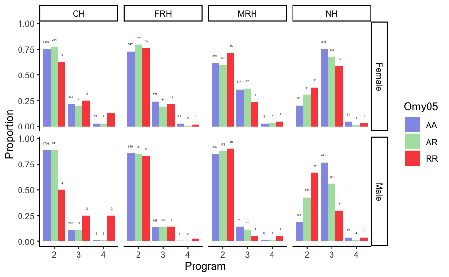

```r
omy_sex <- kid_omy5 %>%
  group_by(hatchery, Omy05, kid_sex) %>%
  count(age_spawn) %>%
  filter(age_spawn <5) %>%
  mutate(total = sum(n), freq = n/sum(n))

omy_sex_gg <- ggplot(omy_sex %>% filter(age_spawn <5))+
  geom_col(aes(x=as.factor(age_spawn), y=freq, fill = Omy05), position = "dodge")+
  facet_grid(kid_sex~hatchery)+
  theme_classic()+
  guides(fill = guide_legend(title="Omy05"))+
  labs(x="Program", y="Proportion")+
  scale_fill_manual(values = c("#959be9","#ace1af", "#f94f4c"))+
  geom_text(aes(y=(freq)+0.07, label=n, group=Omy05, x=as.factor(age_spawn)), position = position_dodge(width = 1), size = 1)

ggsave(plot=omy_sex_gg, file="../figures/Fig4_omy5.png", width = 15, height = 10, units = "cm", dpi = 800)

omy_sex_gg
```

# Frequency of ARxAR spawnings

```r
# bind on ids to cvsh
pedmy5 <- left_join(omy5, cvsh, by=c("NMFS_DNA_ID"="ma")) %>%
  rename("ma_omy05"="Omy05") %>%
  left_join(omy5, ., by=c("NMFS_DNA_ID"="pa")) %>%
  rename("pa_omy05"="Omy05")
# determine ARxAR matings
omy_pairs <- pedmy5 %>%
  filter(!is.na(pa_omy05) & !is.na(ma_omy05)) %>%
  mutate(parent_omy = paste(ma_omy05, "x", pa_omy05))

# filter for trios with AR genotypes in both ma and pa AR
ar_pairs <- omy_pairs %>%
  filter(parent_omy == "AR x AR")

ar_pair_kids <- filter(omy5, NMFS_DNA_ID %in% ar_pairs$kid)
# 466 kids

ar_count <- ar_pair_kids %>%
  group_by(hatchery, sex) %>%
  count(Omy05) %>%
  mutate(total= sum(n), freq = n/sum(n))

ar_count_f <- ar_count %>%
  dplyr::mutate_if(is.numeric, round, 3) %>%
  mutate(final_col = paste(n, " (", (freq*100), "%)", sep="")) %>%
  select(hatchery, Omy05, sex, final_col) %>%
  pivot_wider(names_from = hatchery, values_from = final_col) %>%
  arrange(Omy05)
```

```
`mutate_if()` ignored the following grouping variables:
```

```r
write_csv(ar_count_f, "../tables/S9_omy5AR.csv")
```

## Chi-square

```r
ar.CH.f <- ar_count %>%
  filter(hatchery == "CH" & sex == "Female")
ar.CH.m <- ar_count %>%
  filter(hatchery == "CH" & sex == "Male")
ar.FRH.f <- ar_count %>%
  filter(hatchery == "FRH" & sex == "Female")
ar.FRH.m <- ar_count %>%
  filter(hatchery == "FRH" & sex == "Male")
ar.MRH.f <- ar_count %>%
  filter(hatchery == "MRH" & sex == "Female")
ar.MRH.m <- ar_count %>%
  filter(hatchery == "MRH" & sex == "Male")
ar.NH.f <- ar_count %>%
  filter(hatchery == "NH" & sex == "Female")
ar.NH.m <- ar_count %>%
  filter(hatchery == "NH" & sex == "Male")

ch.ar.f <- ar.CH.f$n
ch.ar.m <- ar.CH.m$n
frh.ar.f <- ar.FRH.f$n
frh.ar.m <- ar.FRH.m$n
mrh.ar.f <- ar.MRH.f$n
mrh.ar.m <- ar.MRH.m$n
nh.ar.f <- ar.NH.f$n
nh.ar.m <- ar.NH.m$n
```

```r
HWch.test.CH.f <- HWChisq(ch.ar.f)
```

```
Chi-square test with continuity correction for Hardy-Weinberg equilibrium (autosomal)
Chi2 =  0.144898 DF =  1 p-value =  0.7034595 D =  0.08333333 f =  -0.02857143
```

```r
HWch.test.CH.m <- HWChisq(ch.ar.m)
```

```
Chi-square test with continuity correction for Hardy-Weinberg equilibrium (autosomal)
Chi2 =  1.874667 DF =  1 p-value =  0.1709416 D =  1.8125 f =  -0.3866667
```

```r
HWch.test.FRH.f <- HWChisq(frh.ar.f)
```

```
Chi-square test with continuity correction for Hardy-Weinberg equilibrium (autosomal)
Chi2 =  4.560682 DF =  1 p-value =  0.03271405 D =  6.756993 f =  -0.1890438
```

```r
HWch.test.FRH.m <- HWChisq(frh.ar.m)
```

```
Chi-square test with continuity correction for Hardy-Weinberg equilibrium (autosomal)
Chi2 =  1.161941 DF =  1 p-value =  0.2810633 D =  2.753125 f =  -0.1394208
```

```r
HWch.test.MRH.f <- HWChisq(mrh.ar.f)
```

```
Chi-square test with continuity correction for Hardy-Weinberg equilibrium (autosomal)
Chi2 =  1.300494 DF =  1 p-value =  0.2541231 D =  1.485294 f =  -0.3699634
```

```r
HWch.test.MRH.m <- HWChisq(mrh.ar.m)
```

```
Chi-square test with continuity correction for Hardy-Weinberg equilibrium (autosomal)
Chi2 =  0.7228571 DF =  1 p-value =  0.3952083 D =  1.083333 f =  -0.3714286
```

```r
HWch.test.NH.f <- HWChisq(nh.ar.f)
```

```
Chi-square test with continuity correction for Hardy-Weinberg equilibrium (autosomal)
Chi2 =  1.88515 DF =  1 p-value =  0.16975 D =  3.366883 f =  -0.1759715
```

```r
HWch.test.NH.m <- HWChisq(nh.ar.m)
```

```
Chi-square test with continuity correction for Hardy-Weinberg equilibrium (autosomal)
Chi2 =  2.342796 DF =  1 p-value =  0.1258635 D =  4.240385 f =  -0.1646137
```

### Overall

Check across programs by sex

```r
ar_counto <- ar_pair_kids %>%
  group_by(sex) %>%
  count(Omy05) %>%
  mutate(total= sum(n), freq = n/sum(n))
of <- ar_counto %>%
  filter(sex=="Female")
of.f <- of$n
HWch.o.f <- HWChisq(of.f)
```

```
Chi-square test with continuity correction for Hardy-Weinberg equilibrium (autosomal)
Chi2 =  7.659792 DF =  1 p-value =  0.005646503 D =  11.28614 f =  -0.1814089
```

```r
om <- ar_counto %>%
  filter(sex=="Male")
om.m <- om$n
HWch.o.m <- HWChisq(om.m)
```

```
Chi-square test with continuity correction for Hardy-Weinberg equilibrium (autosomal)
Chi2 =  6.748273 DF =  1 p-value =  0.009383846 D =  9.782407 f =  -0.1838191
```

### CV only

```r
ar_countcv <- ar_pair_kids %>%
  filter(hatchery != "NH") %>%
  group_by(sex) %>%
  count(Omy05) %>%
  mutate(total= sum(n), freq = n/sum(n))
cvf <- ar_countcv %>%
  filter(sex=="Female")
cvf.f <- cvf$n
HWch.cv.f <- HWChisq(cvf.f)
```

```
Chi-square test with continuity correction for Hardy-Weinberg equilibrium (autosomal)
Chi2 =  5.409884 DF =  1 p-value =  0.02002305 D =  8 f =  -0.1860465
```

```r
cvm <- ar_countcv %>%
  filter(sex=="Male")
cvm.m <- cvm$n
HWch.cv.m <- HWChisq(cvm.m)
```

```
Chi-square test with continuity correction for Hardy-Weinberg equilibrium (autosomal)
Chi2 =  4.018338 DF =  1 p-value =  0.04500805 D =  5.571429 f =  -0.203125
```